# Analyzing sequencing data in the cloud

## A mini example: from a given paper to raw reads

Let’s say we wanted to obtain the ChIP-seq data from an ovarian cancer DNA sample, such as that cited in:

> N Chapman-Rothe et al, “[Chromatin H3K27me3/H3K4me3 histone marks define gene sets in high-grade serous ovarian cancer that distinguish malignant, tumour-sustaining and chemo-resistant ovarian tumour cells](https://pubmed.ncbi.nlm.nih.gov/23128397/)” Oncogene 32(38):4586 (2013).

Visit the full text link for this manuscript from the link above. Note that the manuscript lists an **SRA accession** for the project of ‘*SRP016075*’ under the **Accession codes** section.

Searching for the corresponding record on the SRA database, we will [find a list of the sequencing runs](http://www.ncbi.nlm.nih.gov/sra?term=SRP016075) associated with this manuscript (Figure 6).

[figure not shown]

Figure 6: NCBI SRA search results page for accession SRP016075

Specifically look at the ChIP-seq with the H3K4me3 antibody, which can be found at: https://www.ncbi.nlm.nih.gov/sra/SRX193578. See Figure 7:

[figure not shown]

Figure 7: NCBI SRA page for experiment SRX193578

From the corresponding web page (Figure 7 above), there is a run identifier listed: ‘**SRR600956**’. This is the SRA identifier we need to obtain the raw sequencing data with the `prefetch` program.

```
On AWS
```

```bash
cd
pwd
#/home/ubuntu

prefetch SRR600956

#2023-02-27T20:38:08 prefetch.3.0.1: Current preference is set to retrieve SRA Normalized Format files with full base quality scores.
#2023-02-27T20:38:08 prefetch.3.0.1: 1) Downloading 'SRR600956'...
#2023-02-27T20:38:08 prefetch.3.0.1: SRA Normalized Format file is being retrieved, if this is different from your preference, it may be due to current file availability.
#2023-02-27T20:38:08 prefetch.3.0.1:  Downloading via HTTPS...
#2023-02-27T20:38:27 prefetch.3.0.1:  HTTPS download succeed
#2023-02-27T20:38:28 prefetch.3.0.1:  'SRR600956' is valid
#2023-02-27T20:38:28 prefetch.3.0.1: 1) 'SRR600956' was downloaded successfully
```

Run an `ls` to see the resulting directory - note that the contents here is compressed and not yet usable for further analysis.

To obtain usable raw data we first need to reconstruct the FASTQ file(s) with the **fasterq-dump** program:

```
On AWS
```

```bash
fasterq-dump SRR600956
```

This will take some time but eventually result in a FASTQ file, appearing in your current working directory, which constitutes the raw data from the corresponding sequencing run.

> **Q**. What shell command can you use to view the top few files of your FASTQ file?

> **Q**. What length are these sequence reads?

> **Q**. Can you use the `grep` command to determine how many total reads are in this file?

> **Q**. Does you number of reads from `grep` match the name of the last read in the file? If not why not?

**Tip**

You can use the `head` command to see the start of the resulting FASTQ file and `tail` to see the end.

```
On AWS
```

```bash
head SRR600956.fastq

#@SRR600956.1 HWI-EAS486_0002:3:1:1382:1342 length=38
#GTGTTCCAAATGCTGCAAATGGGTGTCAATGTATGTTA
#+SRR600956.1 HWI-EAS486_0002:3:1:1382:1342 length=38
#D?BCCA?BDBDBACD@=??BAAC>CBBBBBCBBBD?%%
#@SRR600956.2 HWI-EAS486_0002:3:1:1382:5487 length=38
#GATGATAGTTTCTTTTGCCGTTAGCACAATTTTTCCAA
#+SRR600956.2 HWI-EAS486_0002:3:1:1382:5487 length=38
#DCEECEAECEFFDFECEEEFFFFDB?BBADEEEEE???
#@SRR600956.3 HWI-EAS486_0002:3:1:1382:4694 length=38
#TGTAGGCTCCACCTCTGGGGGCAGGGCACAGACAAACA
```

Note that each new read starts with the pattern `@SRR600956`. You can use `grep` with this pattern to determine how many total reads are in this file:

```
On AWS
```

```bash
grep -c "@SRR600956" SRR600956.fastq

#25849655
```

# Working with RNA-Seq data

In this section we will move on to an arguably more interesting RNA-Seq dataset from a human cancer cell line: two replicates of a cell line treated with CRISPR-Cas9 targeting a gene of interest, and two replicates of the cell line treated with a control construct as described in:

> Zhang et al. “[Identification of focally amplified lineage-specific super-enhancers in human epithelial cancers](https://pubmed.ncbi.nlm.nih.gov/26656844/)”. Nat Genet 2016 Feb;48(2):176-82. PMID: 26656844

We will start with their SRA accession numbers, download their raw data and follow up with a complete analysis from raw reads to gene specific counts, principal component analysis and differential expression analysis.

The GEO entry for the study in question can be found at https://www.ncbi.nlm.nih.gov/geo/query/acc.cgi?acc=GSE72001

Let’s use the SRA toolkit to download the study’s data and extract it into FASTQ format:

> **Side-note**: With single-end reads we will have only one file for each sample, with paired-end reads (which are more common in RNA-seq) we will have two files for each sample as we have here.

```
On AWS
```

```bash
prefetch SRR2156848

#2023-02-27T20:47:07 prefetch.3.0.1: Current preference is set to retrieve SRA Normalized Format files with full base quality scores.
#2023-02-27T20:47:07 prefetch.3.0.1: 1) Downloading 'SRR2156848'...
#2023-02-27T20:47:07 prefetch.3.0.1: SRA Normalized Format file is being retrieved, if this is different from your preference, it may be due to current file availability.
#2023-02-27T20:47:07 prefetch.3.0.1:  Downloading via HTTPS...
#2023-02-27T20:47:14 prefetch.3.0.1:  HTTPS download succeed
#2023-02-27T20:47:15 prefetch.3.0.1:  'SRR2156848' is valid
#2023-02-27T20:47:15 prefetch.3.0.1: 1) 'SRR2156848' was downloaded successfully
#2023-02-27T20:47:15 prefetch.3.0.1: 'SRR2156848' has 0 unresolved dependencies
```

Recall that the `prefetch` program prepares temporary files for obtaining sequence data efficiently from the SRA. With this run, you can use `fasterq-dump` to extract the data in FASTQ format to a file in the current directory.

```
On AWS
```

```bash
fasterq-dump SRR2156848

#Read 2959900 spots for SRR2156848
#Written 2959900 spots for SRR2156848
```

Note that as this sequencing run is a paired-end library, this command results in two separate files for the different mate-pairs. Now if we look at the contents of the current directory, we should see the following:

```
On AWS
```

```bash
ls

#SRR2156848/
#SRR2156848_1.fastq
#SRR2156848_2.fastq
```

> **Q**. How would you check that these files with extension ‘.fastq’ actually look like what we expect for a FASTQ file? You could try printing the first few lines to the shell standard output:

```
On AWS
```

```bash
# Fill in the blank!
___ SRR2156848 1.fastq
```

> **Q**. How could you check the number of sequences in each file?

```
On AWS
```

```bash
# Fill in the blanks
____ -___ "___" SRR2156848_1.fastq
2959900
```

> **Q**. Check your answer with the bottom of the file using the `tail` command and also check the matching mate pair FASTQ file. Do these numbers match? If so why or why not?

> **Q.** Download the other 3 datasets (`SRR2156849`, `SRR2156850` and `SRR2156851`) we need for our analysis, first with `prefetch` and then process with `fasterq-dump`

**Tip**

```
On AWS
```

```bash
prefetch SRR2156849 SRR2156850 SRR2156851
fasterq-dump SRR2156849 SRR2156850 SRR2156851
```

> **Q**. Check you have pairs of FASTQ files for all four datasets and that they have the same number of counts in each pair?

```
On AWS
```

```bash
# fill in the blank
___ *.fastq
grep -c "______" *.fastq
```

# Transcript quantification via pseudoalignment

A fast approach to analysis of RNA-seq data makes use of the fact that if you only wish to quantify the expression of a gene, you don’t need to know where in the gene the read maps to. In fact, it is enough to know which genes a read might have come from. This is the principle behind **Kallisto**. In brief, Kallisto compares each RNA-seq read against an indexed table of transcript sequences to find the sets of transcripts that each read could have come from. These sets are then used to estimate the most likely set of transcript counts over the whole RNA-seq library.

- To begin with we need to install kallisto software on our AWS instance:

```
On AWS
```

```bash
wget https://github.com/pachterlab/kallisto/releases/download/v0.44.0/kallisto_linux-v0.44.0.tar.gz

# Unzip and Untar the resulting file
___ -___ kallisto_linux-v0.44.0.tar.gz
```

We can check the program works by calling the `kallisto` executable with its full PATH:

```
On AWS
```

```bash
~/kallisto_linux-v0.44.0/kallisto

#kallisto 0.44.0
#
#Usage: kallisto <CMD> [arguments] ..
#
#Where <CMD> can be one of:
#
#    index         Builds a kallisto index
#    quant         Runs the quantification algorithm
#    pseudo        Runs the pseudoalignment step
#    h5dump        Converts HDF5-formatted results to plaintext
#    inspect       Inspects and gives information about an index
#    version       Prints version information
#    cite          Prints citation information
#
#Running kallisto <CMD> without arguments prints usage information for <CMD>
```

- For ease of use and to avoid having to type the full PATH each time we want to use the program we can add its location to our $PATH environment variable as we did previously for the **sra-tools** package:

```
On AWS
```

```bash
# Fill in the blank
___ PATH=$PATH:/home/ubuntu/kallisto_linux-v0.44.0
```

Now we should be able to run it by simply calling `kallisto`.

> Q. Can you run `kallisto` to print out its citation information?

## Building a transcript index

Let’s pull the **hg19 Ensembl** reference transcriptome directly from the ENSEMBLE ftp site:

- We can use the `wget` command or `curl` command for this.

```
On AWS
```

```bash
wget ftp://ftp.ensembl.org/pub/release-67/fasta/homo_sapiens/cdna/Homo_sapiens.GRCh37.67.cdna.all.fa.gz
```

- Now we need to unzip the downloaded file:

```
On AWS
```

```bash
gunzip Homo_sapiens.GRCh37.67.cdna.all.fa.gz
```

- Now we can use Kallisto’s index program to build the transcriptome index (N.B. this can take some time):

```
On AWS
```

```bash
kallisto index -i hg19.ensembl Homo_sapiens.GRCh37.67.cdna.all.fa
```

This command specified that we give this transcriptome index the name `hg19.ensembl`. *This will take a little while*.

Once complete we will have an *indexed human transcriptome* to match the reads against, we can then use Kallisto for fast transcript quantification on our FASTQ files.

## Quantifying transcripts

To quantify transcripts with Kallisto we use the `quant` command option, specifying a transcript index (with the `-i` flag), an output directory (with the `-o` flag) in which to write results to file, and a list of our Fastq input files:

- Run transcript quantification for the pair of SRR2156848 FASTQ files:

```
On AWS
```

```bash
kallisto quant -i hg19.ensembl -o SRR2156848_quant SRR2156848_1.fastq SRR2156848_2.fastq
```

This again will take some time (but not nearly as long as the alignment based mapping we did on our previous galaxy lab).

- Once run correctly, there should be three new files in the `SRR2156848_quant` directory:

```
On AWS
```

```bash
ls SRR2156848_quant
abundance.h5  abundance.tsv  run_info.json
```

> **Q**. Now run the quantification calculation for the remaining samples:

```
On AWS
```

```bash
# You complete these steps
kallisto quant -i ___ -o SRR2156849_quant SRR2156849_1.fastq SRR2156849_2.fastq

kallisto quant -i hg19.ensembl -o SRR2156850_quant ___.fastq ___.fastq

kallisto quant -i hg19.ensembl -o SRR2156851_quant SRR2156851_1.fastq SRR2156851_2.fastq
```

## Scripting repetitive tasks

Rather than running `kallisto quant` separately for each of our remaining three samples, this is a good opportunity to write a simple **shell script**.

Scripting repetitive tasks is one of the most important habits to develop in bioinformatics. Not only does it save time and reduce the chance of typos creeping into individual commands, it also makes your analysis **reproducible** — anyone (including your future self) can re-run the entire analysis by executing a single file.

Just like writing functions in R, whenever you find yourself copy-pasting a command and changing only one small thing each time, that’s a signal that a shell script with a loop would serve you better.

- Use a text editor (e.g. `nano`) to create a script called `run_kallisto.sh`:

```
On AWS
```

```bash
nano run_kallisto.sh
```

- Add the following to the file, save, and exit (`Ctrl+O`, `Enter`, `Ctrl+X`):

```
run_kallisto.sh
```

```bash
#!/bin/bash
# Transcript quantification with Kallisto for samples SRR2156849-51

for id in SRR2156849 SRR2156850 SRR2156851; do
  echo "Processing sample: $id"
  kallisto quant -i hg19.ensembl -o ${id}_quant ${id}_1.fastq ${id}_2.fastq
done

echo "All samples complete!"
```

- Make the script executable and run it:

```
On AWS
```

```bash
chmod +x run_kallisto.sh
./run_kallisto.sh
```

The `echo` statements act as progress markers so you can track which sample is currently being processed.

### Check your results

You should now have a `*_quant/` directory for each sample.

> **Q**. Have a look at the TSV format versions of these files to understand their structure. What do you notice about these files contents?

## Transfer your results

With the transcript quantification completed, we are now finished our UNIX intensive work on AWS.

We can thus transfer our main results files to date (the various `abundance.tsv` files) back to our laptop for further analysis.

- On your computer (i.e. open a new Terminal) navigate to a directory where you want to store your results and use `scp` to transfer all your abundance results to this directory.

```
On YOUR computer
```

```bash
# Make sure you are accessing your keyfile and instance
scp -r -i ~/Downloads/bimm143w23.pem ubuntu@ec2-34-219-113-54.us-west-2.compute.amazonaws.com:~/*_quant .
```

To make this command simpler to type you can use your **shell environment variables** from earlier.

```
On YOUR computer
```

```bash
# Change these to match your key and instance address:
export KEY=~/Downloads/bioinf_barry.pem
export SERVER=ubuntu@ec2-34-210-54-74.us-west-2.compute.amazonaws.com

# Transfer results back to your current directory
scp -r -i $KEY $SERVER:~/*_quant .
```

# IMPORTANT: Stop your instance!

Please **Stop** your AWS instances at this point as we want to conserve funds for future work. To stop your instance:

- Return to the AWS console by visiting https://awsed.ucsd.edu/,
- Select your running instance,
- Click “Instance State” > “Stop” to suspend and stop being charged for resources.

# Downstream analysis

Back on our laptop we can now use R and Bioconductor tools to further explore this large scale data-set.

For example there is an R function called `tximport()` in the **tximport** package, which enables straightforward import of Kallisto results.

With each sample having its own directory containing the Kallisto output, we can import the transcript count estimates into R using:

```r
# BiocManager::install("tximport")
```

```r
library(tximport)

# setup the folder and file-names to read
folders <- dir(pattern="SRR21568*")
samples <- sub("_quant", "", folders)
files <- file.path( folders, "abundance.h5" )
names(files) <- samples

txi.kallisto <- tximport(files, type = "kallisto", txOut = TRUE)
```

```
1 2 3 4
```

```r
head(txi.kallisto$counts)
```

```
                SRR2156848 SRR2156849 SRR2156850 SRR2156851
ENST00000539570          0          0    0.00000          0
ENST00000576455          0          0    2.62037          0
ENST00000510508          0          0    0.00000          0
ENST00000474471          0          1    1.00000          0
ENST00000381700          0          0    0.00000          0
ENST00000445946          0          0    0.00000          0
```

We now have our estimated transcript counts for each sample in R. We can see how many transcripts we have for each sample:

```r
colSums(txi.kallisto$counts)
```

```
SRR2156848 SRR2156849 SRR2156850 SRR2156851
   2563611    2600800    2372309    2111474
```

And how many transcripts are detected in at least one sample:

```r
sum(rowSums(txi.kallisto$counts)>0)
```

```
[1] 94561
```

Before subsequent analysis, we might want to filter out those annotated transcripts with no reads:

```r
to.keep <- rowSums(txi.kallisto$counts) > 0
kset.nonzero <- txi.kallisto$counts[to.keep,]
```

And those with no change over the samples:

```r
keep2 <- apply(kset.nonzero,1,sd)>0
x <- kset.nonzero[keep2,]
```

## Principal Component Analysis

We can now apply any exploratory analysis technique to this counts matrix. As an example, we will perform a PCA of the transcriptomic profiles of these samples.

Now we compute the principal components, centering and scaling each transcript’s measured levels so that each feature contributes equally to the PCA:

```r
pca <- prcomp(t(x), scale=TRUE)
```

```r
summary(pca)
```

```
Importance of components:
                            PC1      PC2      PC3   PC4
Standard deviation     183.6379 177.3605 171.3020 1e+00
Proportion of Variance   0.3568   0.3328   0.3104 1e-05
Cumulative Proportion    0.3568   0.6895   1.0000 1e+00
```

Now we can use the first two principal components as a co-ordinate system for visualizing the summarized transcriptomic profiles of each sample:

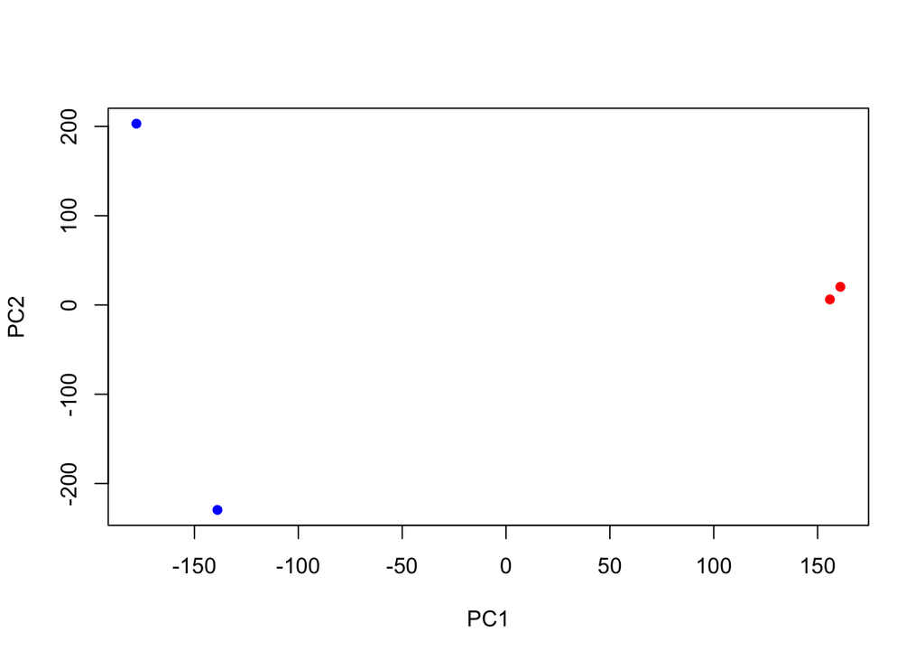

```r
plot(pca$x[,1], pca$x[,2],
     col=c("blue","blue","red","red"),
     xlab="PC1", ylab="PC2", pch=16)
```

> Q. Use ggplot to make a similar figure of PC1 vs PC2 and a separate figure PC1 vs PC3 and PC2 vs PC3.

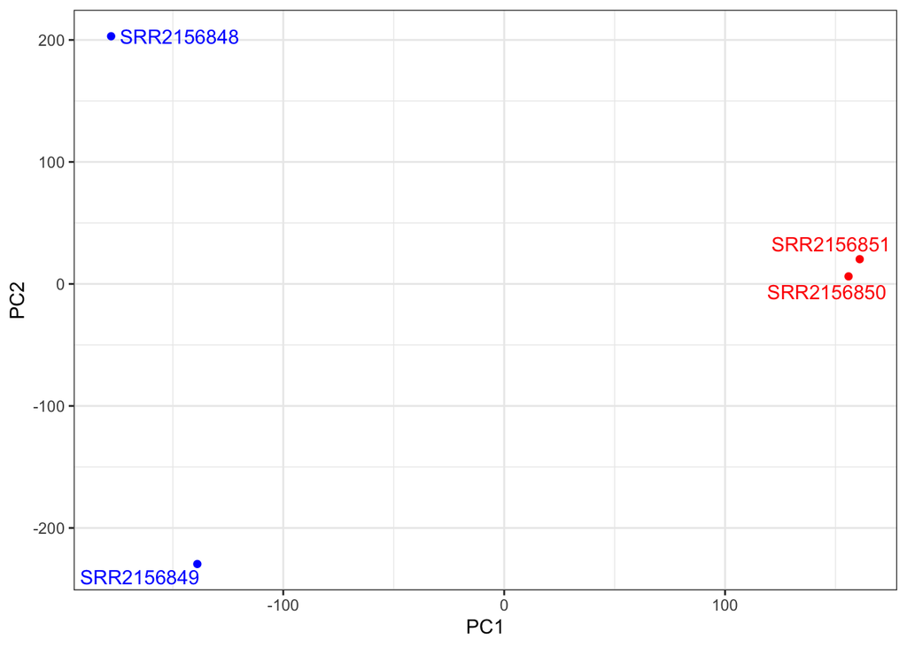

```r
library(ggplot2)
library(ggrepel)

mycols <- c("blue","blue","red","red")

ggplot(pca$x) +
  aes(PC1, PC2, label=rownames(pca$x)) +
  geom_point( col=mycols ) +
  geom_text_repel( col=mycols ) +
  theme_bw()
```

The plot makes it clear that PC1 separates the two control samples (SRR2156848 and SRR2156849) from the two enhancer-targeting CRISPR-Cas9 samples (SRR2156850 and SRR2156851). PC2 separates the two control samples from each other, and PC3 separates the two enhancer-targeting CRISPR samples from each other. This could be investigated further to see which genes result in these separation patterns. It is also at least slightly reassuring, implying that there are considerable differences between the treated and control samples.

## OPTIONAL: Differential-expression analysis

We can use **DESeq2** to complete the differential-expression analysis that we are already familiar with:

An example of creating a DESeqDataSet for use with DESeq2:

```r
library(DESeq2)
```

```r
sampleTable <- data.frame(condition = factor(rep(c("control", "treatment"), each = 2)))
rownames(sampleTable) <- colnames(txi.kallisto$counts)
```

```r
dds <- DESeqDataSetFromTximport(txi.kallisto,
                                sampleTable,
                                ~condition)
```

```
using counts and average transcript lengths from tximport
```

```r
# dds is now ready for DESeq() see our previous classes on this
```

```r
dds <- DESeq(dds)
```

```r
res <- results(dds)
head(res)
```

```
log2 fold change (MLE): condition treatment vs control
Wald test p-value: condition treatment vs control
DataFrame with 6 rows and 6 columns
                 baseMean log2FoldChange     lfcSE      stat    pvalue
                <numeric>      <numeric> <numeric> <numeric> <numeric>
ENST00000539570  0.000000             NA        NA        NA        NA
ENST00000576455  0.761453       3.155061   4.86052 0.6491203  0.516261
ENST00000510508  0.000000             NA        NA        NA        NA
ENST00000474471  0.484938       0.181923   4.24871 0.0428185  0.965846
ENST00000381700  0.000000             NA        NA        NA        NA
ENST00000445946  0.000000             NA        NA        NA        NA
                     padj
                <numeric>
ENST00000539570        NA
ENST00000576455        NA
ENST00000510508        NA
ENST00000474471        NA
ENST00000381700        NA
ENST00000445946        NA
```

These results could go on to be visualized and subjected to pathway analysis etc. as we have done in previous classes.